# **London Household Energy Usage**

#### **Fall 2024 Data Science Project**

Collaborators: Joseph Cho, Aditya Shelke, Ishaan Ghosh, & Grace Cai

#### **Contributions**

**Joseph Cho**

I helped with data cleaning, helped with the Kruskal Wallis test on acorn groups, and contributed to the development and presentation of our PROPHET and LSTM models, specifically the implementation and feature engineering.

**Aditya Shelke**

For the exploratory data analysis, I worked on the Friedman test for seasonality. In addition, I was part of the data cleaning process and the development of our LSTM (long - short term memory) model to predict energy usage for 30 days given the last 30 days of data.

**Ishaan Ghosh**

I helped with the data exploration and hypothesis testing, and the final report creation. I did the Wilcoxon Signed-Rank Test to analyze differences in energy consumption on weekends vs. weekdays, contributed to our introduction and conclusion, and added a couple visualizations.

**Grace Cai**

I helped with dataset curation and preprocessing by explaining why we chose the London energy dataset and adding acorn group to the energy data for each household. I created the graph comparing average energy consumption for each acorn and analyzed specific information from each household such as number of members.

1. Introduction
2. Data Curation
3. Exploratory Data Analysis
4. Primary Analysis
5. Insights and Conclusions

## **Introduction**

Our project aims to use time series data of energy consumption for a certain household to predict future energy consumption. We examine the following data for our analysis:

- Energy consumption
- Acorn (category based on household demographics)
- Temperature
- Humidity
- Wind speed
- Weekend
- Season

We want to answer the following questions:

- How does energy consumption differ between Acorn groups?
- How does the temperature affect the energy consumption?
- How do temporal factors affect energy consumption? Are there seasonal trends?
- Over the years, how will energy consumption increase/decrease?

Answering these questions is important to understand how energy consumption changes due to weather and season. We hypothesize that lower temperatures in the winter will lead to increased energy usage due to increased usage of heaters. In addition, being able to predict how energy consumption will change in the future can help energy companies take measures to handle an increase in energy consumption. Individual households can also use this information to understand their own energy usage habits so they can be more mindful of the environment.

## **Data Curation**

#### **Data Source**

https://www.kaggle.com/datasets/jeanmidev/smart-meters-in-london/data

#### **What dataset did we choose?**

The dataset we utilized was gathered as part of the Low Carbon London Project, which was an energy data collection scheme that ran in London, UK between the years 2011 to 2014, inclusive. The project involved installing smart meters in 5,566 households of varying income levels. Between 2011-11-23 and 2014-02-28, energy consumption was recorded for each household at 30 minute increments. This data was also represented in a daily fashion, where for each day for each household, the mean and standard deviation energy consumption for a thirty minute block was recorded. In addition to this, for each day for each household, the total energy consumption throughout the entire day was also recorded.

Each household is categorized into an Acorn group, which represents a specific type of household. Acorn groups are a method utilized in the United Kingdom to categorize households based on their general similarity. For example, Acorn group Acorn-O represents “Stable Seniors” which is a large subset of the population of seniors who are solid middle class. Acorn groups include Acorn-A through Acorn-U (with the exception of R, S, T) in this dataset. Acorn groups are classified into Acorn Categories based on their similar income and wealth levels. There are households of 6 Acorn Categories present in this data (all included in the image below except “Not Private Households”).

As part of the Low Carbon London Project, each household involved in the study had to provide information regarding their household and residence. They had to provide information including the number of rooms, number of bedrooms, and number of members of the household, which are the columns of data we take most interest in.

Finally, we also have daily temperature and weather data for London collected via the DarkSky API. This information is separate from the LCLP, but it is nonetheless useful to understanding the relationship between weather and energy usage.

[figure not shown]

#### **Imports**

```python
!pip install scikit_posthocs --quiet
```

```python
import pandas as pd
import matplotlib.pyplot as plt
import seaborn as sns
import numpy as np
from math import sqrt
from scipy import stats
from scipy.signal import periodogram
import scikit_posthocs as sp
from datetime import datetime
import statsmodels.api as sm
from statsmodels.tsa.stattools import adfuller
```

#### **Mounting Data From Google Drive**

```python
from google.colab import drive
drive.mount('/content/drive', force_remount=True)
```

```python
%cd /content/drive/My Drive/CMSC320 Project/
```

```
/content/drive/.shortcut-targets-by-id/1g2WDnYtwYUjrEX205HTh8ABD7cyoW0Tf/CMSC320 Project
```

#### **Overview of Tables**

**daily_df:** The first table of data we have is daily_df. Each row of this table represents the energy usage statistics for a single household on a single day (24 - hour period of time). The column LCLid represents the unique identifier for each household. The column energy_median, energy_mean, and energy_std represent the median, mean, and standard deviation of energy consumption per 30 minute period in the day. Consider that the Low Carbon London project collects data at 30 minute intervals. Then, for 48 intervals in the day, there is a measure of energy consumption for a household. Then, energy_median, energy_mean, and energy_std represent the median, mean, and standard deviation of energy consumption from those 48 intervals.

The column energy_max and energy_min represent the maximum and minimum energy consumption measurements, and energy_sum represents the total energy consumption of a household in a particular day.

```python
daily_df = pd.read_csv("data/daily_dataset.csv")
daily_df
```

|  | LCLid | day | energy_median | energy_mean | energy_max | energy_count | energy_std | energy_sum | energy_min |
| --- | --- | --- | --- | --- | --- | --- | --- | --- | --- |
| 0 | MAC000131 | 2011-12-15 | 0.4850 | 0.432045 | 0.868 | 22 | 0.239146 | 9.505 | 0.072 |
| 1 | MAC000131 | 2011-12-16 | 0.1415 | 0.296167 | 1.116 | 48 | 0.281471 | 14.216 | 0.031 |
| 2 | MAC000131 | 2011-12-17 | 0.1015 | 0.189812 | 0.685 | 48 | 0.188405 | 9.111 | 0.064 |
| 3 | MAC000131 | 2011-12-18 | 0.1140 | 0.218979 | 0.676 | 48 | 0.202919 | 10.511 | 0.065 |
| 4 | MAC000131 | 2011-12-19 | 0.1910 | 0.325979 | 0.788 | 48 | 0.259205 | 15.647 | 0.066 |
| ... | ... | ... | ... | ... | ... | ... | ... | ... | ... |
| 3510428 | MAC004977 | 2014-02-24 | 0.0950 | 0.118458 | 0.580 | 48 | 0.093814 | 5.686 | 0.052 |
| 3510429 | MAC004977 | 2014-02-25 | 0.0675 | 0.084208 | 0.176 | 48 | 0.037107 | 4.042 | 0.046 |
| 3510430 | MAC004977 | 2014-02-26 | 0.1080 | 0.120500 | 0.282 | 48 | 0.069332 | 5.784 | 0.046 |
| 3510431 | MAC004977 | 2014-02-27 | 0.0720 | 0.114062 | 0.431 | 48 | 0.094482 | 5.475 | 0.047 |
| 3510432 | MAC004977 | 2014-02-28 | 0.0970 | 0.097000 | 0.097 | 1 | NaN | 0.097 | 0.097 |

3510433 rows × 9 columns

**households_df:** This dataset maps each household ID to an acorn between ACORN-A and ACORN-U inclusive. LCLid is the unique identifier for each household. The column stdorToU is the kind of tariff applied (ToU the dynamic tariff in function of the days or Std the classic fixed tariff). Acorn is the acorn group that categorizes the household. Acorns_grouped is a more generalized classification of the household, however, we use a different grouping system from the same organization that made the acorn system (shown in image above). File is the name of the file that the household's data is in.

```python
households_df = pd.read_csv("data/informations_households.csv")
households_df = households_df[households_df['Acorn'] != "ACORN-"]
groupings = {}
for acorn in ['ACORN-A', 'ACORN-B', 'ACORN-C']:
  groupings[acorn] = "Luxury"
for acorn in ['ACORN-D', 'ACORN-E']:
  groupings[acorn] = "Established"
for acorn in ['ACORN-F', 'ACORN-G', 'ACORN-H', 'ACORN-I', 'ACORN-J']:
  groupings[acorn] = "Thriving"
for acorn in ['ACORN-K', 'ACORN-L', 'ACORN-M', 'ACORN-N', 'ACORN-O']:
  groupings[acorn] = "Steadfast"
for acorn in ['ACORN-P', 'ACORN-Q', 'ACORN-R']:
  groupings[acorn] = "Stretched"
for acorn in ['ACORN-S', 'ACORN-T', 'ACORN-U']:
  groupings[acorn] = "Low Income"
groupings['ACORN-'] = "No Category"

households_df['Acorn_category'] = households_df['Acorn'].map(lambda acorn: groupings[acorn])
households_df
```

|  | LCLid | stdorToU | Acorn | Acorn_grouped | file | Acorn_category |
| --- | --- | --- | --- | --- | --- | --- |
| 2 | MAC000002 | Std | ACORN-A | Affluent | block_0 | Luxury |
| 3 | MAC003613 | Std | ACORN-A | Affluent | block_0 | Luxury |
| 4 | MAC003597 | Std | ACORN-A | Affluent | block_0 | Luxury |
| 5 | MAC003579 | Std | ACORN-A | Affluent | block_0 | Luxury |
| 6 | MAC003566 | Std | ACORN-A | Affluent | block_0 | Luxury |
| ... | ... | ... | ... | ... | ... | ... |
| 5561 | MAC002056 | Std | ACORN-U | ACORN-U | block_111 | Low Income |
| 5562 | MAC004587 | Std | ACORN-U | ACORN-U | block_111 | Low Income |
| 5563 | MAC004828 | Std | ACORN-U | ACORN-U | block_111 | Low Income |
| 5564 | MAC001704 | ToU | ACORN-U | ACORN-U | block_111 | Low Income |
| 5565 | MAC002774 | ToU | ACORN-U | ACORN-U | block_111 | Low Income |

5564 rows × 6 columns

**weather_df:** This table of data maps each date in the range of dates we are interested in (2011 to 2014) to the weather on that day. We look at specific columns such as temperatureLow, temperatureHigh, and both of these values to calculate the average temperature for each day.

```python
weather_df = pd.read_csv("data/weather_daily_darksky.csv")
weather_df["date"] = pd.to_datetime(pd.to_datetime(weather_df["temperatureHighTime"]).dt.date)
weather_df["temperatureAverage"] = (weather_df["temperatureLow"] + weather_df["temperatureHigh"]) / 2
weather_df
```

|  | temperatureMax | temperatureMaxTime | windBearing | icon | dewPoint | temperatureMinTime | cloudCover | windSpeed | pressure | apparentTemperatureMinTime | ... | temperatureHighTime | uvIndexTime | summary | temperatureLowTime | apparentTemperatureMin | apparentTemperatureMaxTime | apparentTemperatureLowTime | moonPhase | date | temperatureAverage |
| --- | --- | --- | --- | --- | --- | --- | --- | --- | --- | --- | --- | --- | --- | --- | --- | --- | --- | --- | --- | --- | --- |
| 0 | 11.96 | 2011-11-11 23:00:00 | 123 | fog | 9.40 | 2011-11-11 07:00:00 | 0.79 | 3.88 | 1016.08 | 2011-11-11 07:00:00 | ... | 2011-11-11 19:00:00 | 2011-11-11 11:00:00 | Foggy until afternoon. | 2011-11-11 19:00:00 | 6.48 | 2011-11-11 23:00:00 | 2011-11-11 19:00:00 | 0.52 | 2011-11-11 | 10.870 |
| 1 | 8.59 | 2011-12-11 14:00:00 | 198 | partly-cloudy-day | 4.49 | 2011-12-11 01:00:00 | 0.56 | 3.94 | 1007.71 | 2011-12-11 02:00:00 | ... | 2011-12-11 14:00:00 | 2011-12-11 12:00:00 | Partly cloudy throughout the day. | 2011-12-12 07:00:00 | 0.11 | 2011-12-11 20:00:00 | 2011-12-12 08:00:00 | 0.53 | 2011-12-11 | 5.840 |
| 2 | 10.33 | 2011-12-27 02:00:00 | 225 | partly-cloudy-day | 5.47 | 2011-12-27 23:00:00 | 0.85 | 3.54 | 1032.76 | 2011-12-27 22:00:00 | ... | 2011-12-27 14:00:00 | 2011-12-27 00:00:00 | Mostly cloudy throughout the day. | 2011-12-27 23:00:00 | 5.59 | 2011-12-27 02:00:00 | 2011-12-28 00:00:00 | 0.10 | 2011-12-27 | 9.180 |
| 3 | 8.07 | 2011-12-02 23:00:00 | 232 | wind | 3.69 | 2011-12-02 07:00:00 | 0.32 | 3.00 | 1012.12 | 2011-12-02 07:00:00 | ... | 2011-12-02 12:00:00 | 2011-12-02 10:00:00 | Partly cloudy throughout the day and breezy ov... | 2011-12-02 19:00:00 | 0.46 | 2011-12-02 12:00:00 | 2011-12-02 19:00:00 | 0.25 | 2011-12-02 | 6.845 |
| 4 | 8.22 | 2011-12-24 23:00:00 | 252 | partly-cloudy-night | 2.79 | 2011-12-24 07:00:00 | 0.37 | 4.46 | 1028.17 | 2011-12-24 07:00:00 | ... | 2011-12-24 15:00:00 | 2011-12-24 13:00:00 | Mostly cloudy throughout the day. | 2011-12-24 19:00:00 | -0.51 | 2011-12-24 23:00:00 | 2011-12-24 20:00:00 | 0.99 | 2011-12-24 | 7.690 |
| ... | ... | ... | ... | ... | ... | ... | ... | ... | ... | ... | ... | ... | ... | ... | ... | ... | ... | ... | ... | ... | ... |
| 877 | 9.03 | 2014-01-26 16:00:00 | 233 | partly-cloudy-day | 2.39 | 2014-01-26 21:00:00 | 0.40 | 4.55 | 1002.10 | 2014-01-26 22:00:00 | ... | 2014-01-26 16:00:00 | 2014-01-26 11:00:00 | Mostly cloudy until evening. | 2014-01-27 05:00:00 | -1.30 | 2014-01-26 15:00:00 | 2014-01-27 04:00:00 | 0.84 | 2014-01-26 | 5.795 |
| 878 | 10.31 | 2014-02-27 14:00:00 | 224 | partly-cloudy-day | 3.08 | 2014-02-27 23:00:00 | 0.32 | 4.14 | 1007.02 | 2014-02-27 22:00:00 | ... | 2014-02-27 14:00:00 | 2014-02-27 12:00:00 | Partly cloudy until evening. | 2014-02-28 02:00:00 | 1.41 | 2014-02-27 14:00:00 | 2014-02-28 02:00:00 | 0.93 | 2014-02-27 | 6.870 |
| 879 | 18.97 | 2014-03-09 14:00:00 | 172 | partly-cloudy-night | 4.30 | 2014-03-09 07:00:00 | 0.04 | 2.78 | 1022.44 | 2014-03-09 07:00:00 | ... | 2014-03-09 14:00:00 | 2014-03-09 12:00:00 | Partly cloudy in the evening. | 2014-03-10 05:00:00 | 7.08 | 2014-03-09 14:00:00 | 2014-03-10 06:00:00 | 0.28 | 2014-03-09 | 12.005 |
| 880 | 8.83 | 2014-02-12 16:00:00 | 210 | wind | 1.94 | 2014-02-12 01:00:00 | 0.59 | 7.24 | 994.27 | 2014-02-12 01:00:00 | ... | 2014-02-12 16:00:00 | 2014-02-12 10:00:00 | Mostly cloudy until evening and breezy through... | 2014-02-13 05:00:00 | -1.20 | 2014-02-12 16:00:00 | 2014-02-13 02:00:00 | 0.42 | 2014-02-12 | 6.485 |
| 881 | 9.90 | 2014-02-15 12:00:00 | 233 | wind | 2.95 | 2014-02-15 23:00:00 | 0.35 | 9.96 | 988.63 | 2014-02-15 23:00:00 | ... | 2014-02-15 12:00:00 | 2014-02-15 10:00:00 | Windy and mostly cloudy until afternoon. | 2014-02-16 07:00:00 | 1.77 | 2014-02-15 12:00:00 | 2014-02-16 07:00:00 | 0.52 | 2014-02-15 | 6.120 |

882 rows × 34 columns

**acorn_df:** This table of data provides information for each ACORN group. We can understand the table as follows. Each row of the table is an attribute, and a numerical value is provided based on that attribute for each of the ACORN groups. A value of 150, for example, means that for the given attribute, the ACORN group with the value 150 has 1.5 times more people with that attribute than on average. For example, consider row 0. We see that ACORN-B has a value of 83. This means that ACORN-B has 0.83 times the average number of 0 - 4 year olds at the national scale.

```python
acorn_df = pd.read_csv("data/acorn_details.csv", encoding='iso-8859-1')
acorn_df
```

|  | MAIN CATEGORIES | CATEGORIES | REFERENCE | ACORN-A | ACORN-B | ACORN-C | ACORN-D | ACORN-E | ACORN-F | ACORN-G | ACORN-H | ACORN-I | ACORN-J | ACORN-K | ACORN-L | ACORN-M | ACORN-N | ACORN-O | ACORN-P | ACORN-Q |
| --- | --- | --- | --- | --- | --- | --- | --- | --- | --- | --- | --- | --- | --- | --- | --- | --- | --- | --- | --- | --- |
| 0 | POPULATION | Age | Age 0-4 | 77.0 | 83.0 | 72.0 | 100.0 | 120.0 | 77.0 | 97.0 | 97.0 | 63.0 | 119.0 | 67.0 | 114.0 | 113.0 | 89.0 | 123.0 | 138.0 | 133.0 |
| 1 | POPULATION | Age | Age 5-17 | 117.0 | 109.0 | 87.0 | 69.0 | 94.0 | 95.0 | 102.0 | 106.0 | 67.0 | 95.0 | 64.0 | 108.0 | 116.0 | 86.0 | 89.0 | 136.0 | 106.0 |
| 2 | POPULATION | Age | Age 18-24 | 64.0 | 73.0 | 67.0 | 107.0 | 100.0 | 71.0 | 83.0 | 89.0 | 62.0 | 104.0 | 459.0 | 97.0 | 96.0 | 86.0 | 117.0 | 109.0 | 110.0 |
| 3 | POPULATION | Age | Age 25-34 | 52.0 | 63.0 | 62.0 | 197.0 | 151.0 | 66.0 | 90.0 | 88.0 | 63.0 | 132.0 | 145.0 | 109.0 | 96.0 | 90.0 | 140.0 | 120.0 | 120.0 |
| 4 | POPULATION | Age | Age 35-49 | 102.0 | 105.0 | 91.0 | 124.0 | 118.0 | 93.0 | 102.0 | 103.0 | 76.0 | 111.0 | 67.0 | 99.0 | 98.0 | 90.0 | 102.0 | 103.0 | 100.0 |
| ... | ... | ... | ... | ... | ... | ... | ... | ... | ... | ... | ... | ... | ... | ... | ... | ... | ... | ... | ... | ... |
| 821 | LEISURE TIME | Holiday Destination/Type | Asia | 171.0 | 137.0 | 94.0 | 220.0 | 196.0 | 69.0 | 122.0 | 95.0 | 72.0 | 97.0 | 124.0 | 73.0 | 57.0 | 49.0 | 96.0 | 113.0 | 63.0 |
| 822 | LEISURE TIME | Holiday Destination/Type | Activity / Outdoor Sports | 298.0 | 278.0 | 138.0 | 119.0 | 93.0 | 96.0 | 113.0 | 96.0 | 84.0 | 96.0 | 56.0 | 48.0 | 48.0 | 46.0 | 23.0 | 23.0 | 23.0 |
| 823 | LEISURE TIME | Holiday Destination/Type | Cruise | 272.0 | 295.0 | 272.0 | 44.0 | 44.0 | 70.0 | 70.0 | 70.0 | 70.0 | 70.0 | 28.0 | 28.0 | 28.0 | 28.0 | 49.0 | 49.0 | 49.0 |
| 824 | LEISURE TIME | Holiday Destination/Type | Package | 196.0 | 186.0 | 166.0 | 49.0 | 49.0 | 101.0 | 101.0 | 121.0 | 106.0 | 101.0 | 48.0 | 75.0 | 75.0 | 75.0 | 54.0 | 54.0 | 54.0 |
| 825 | LEISURE TIME | Holiday Destination/Type | Self-catering | 308.0 | 181.0 | 181.0 | 55.0 | 55.0 | 127.0 | 147.0 | 124.0 | 113.0 | 166.0 | 44.0 | 44.0 | 44.0 | 33.0 | 32.0 | 35.0 | 35.0 |

826 rows × 20 columns

```python
# replacing acorn columns with acorn category columns
acorn_category_df = pd.DataFrame({'Category': acorn_df['CATEGORIES'], 'Reference': acorn_df['REFERENCE']})
acorn_category_df['Luxury'] = acorn_df['ACORN-A'] + acorn_df['ACORN-B'] + acorn_df['ACORN-C']
acorn_category_df['Established'] = acorn_df['ACORN-D'] + acorn_df['ACORN-E']
acorn_category_df['Thriving'] = acorn_df['ACORN-F'] + acorn_df['ACORN-G'] + acorn_df['ACORN-H'] + acorn_df['ACORN-I'] + acorn_df['ACORN-J']
acorn_category_df['Steadfast'] = acorn_df['ACORN-K'] + acorn_df['ACORN-L'] + acorn_df['ACORN-M'] + acorn_df['ACORN-N'] + acorn_df['ACORN-O']
acorn_category_df['Stretched'] = acorn_df['ACORN-P'] + acorn_df['ACORN-Q']
# acorn_category_df['No Category'] = acorn_df['ACORN-']
acorn_category_df
```

|  | Category | Reference | Luxury | Established | Thriving | Steadfast | Stretched |
| --- | --- | --- | --- | --- | --- | --- | --- |
| 0 | Age | Age 0-4 | 232.0 | 220.0 | 453.0 | 506.0 | 271.0 |
| 1 | Age | Age 5-17 | 313.0 | 163.0 | 465.0 | 463.0 | 242.0 |
| 2 | Age | Age 18-24 | 204.0 | 207.0 | 409.0 | 855.0 | 219.0 |
| 3 | Age | Age 25-34 | 177.0 | 348.0 | 439.0 | 580.0 | 240.0 |
| 4 | Age | Age 35-49 | 298.0 | 242.0 | 485.0 | 456.0 | 203.0 |
| ... | ... | ... | ... | ... | ... | ... | ... |
| 821 | Holiday Destination/Type | Asia | 402.0 | 416.0 | 455.0 | 399.0 | 176.0 |
| 822 | Holiday Destination/Type | Activity / Outdoor Sports | 714.0 | 212.0 | 485.0 | 221.0 | 46.0 |
| 823 | Holiday Destination/Type | Cruise | 839.0 | 88.0 | 350.0 | 161.0 | 98.0 |
| 824 | Holiday Destination/Type | Package | 548.0 | 98.0 | 530.0 | 327.0 | 108.0 |
| 825 | Holiday Destination/Type | Self-catering | 670.0 | 110.0 | 677.0 | 197.0 | 70.0 |

826 rows × 7 columns

#### **Data Cleaning**

**Checking data types as a sanity check**

```python
daily_df.dtypes
```

|  | 0 |
| --- | --- |
| LCLid | object |
| day | object |
| energy_median | float64 |
| energy_mean | float64 |
| energy_max | float64 |
| energy_count | int64 |
| energy_std | float64 |
| energy_sum | float64 |
| energy_min | float64 |

**dtype:** object

**Create column "date" that converts the "day" column to datetime format**

```python
daily_df.insert(1, "date", pd.to_datetime(daily_df.pop("day"), format="%Y-%m-%d"))
daily_df.head()
```

|  | LCLid | date | energy_median | energy_mean | energy_max | energy_count | energy_std | energy_sum | energy_min |
| --- | --- | --- | --- | --- | --- | --- | --- | --- | --- |
| 0 | MAC000131 | 2011-12-15 | 0.4850 | 0.432045 | 0.868 | 22 | 0.239146 | 9.505 | 0.072 |
| 1 | MAC000131 | 2011-12-16 | 0.1415 | 0.296167 | 1.116 | 48 | 0.281471 | 14.216 | 0.031 |
| 2 | MAC000131 | 2011-12-17 | 0.1015 | 0.189812 | 0.685 | 48 | 0.188405 | 9.111 | 0.064 |
| 3 | MAC000131 | 2011-12-18 | 0.1140 | 0.218979 | 0.676 | 48 | 0.202919 | 10.511 | 0.065 |
| 4 | MAC000131 | 2011-12-19 | 0.1910 | 0.325979 | 0.788 | 48 | 0.259205 | 15.647 | 0.066 |

**Double check that date is the correct data type**

```python
daily_df.dtypes
```

|  | 0 |
| --- | --- |
| LCLid | object |
| date | datetime64[ns] |
| energy_median | float64 |
| energy_mean | float64 |
| energy_max | float64 |
| energy_count | int64 |
| energy_std | float64 |
| energy_sum | float64 |
| energy_min | float64 |

**dtype:** object

**Check for missing data in each column**

```python
missing_data = daily_df.isna().sum()
missing_data
```

|  | 0 |
| --- | --- |
| LCLid | 0 |
| date | 0 |
| energy_median | 30 |
| energy_mean | 30 |
| energy_max | 30 |
| energy_count | 0 |
| energy_std | 11331 |
| energy_sum | 30 |
| energy_min | 30 |

**dtype:** int64

**Check the percentage of missing data for the entire dataset**

```python
missing_data["energy_std"] / len(daily_df)
```

```
0.003227806940055543
```

**Drop the missing data since it is less than 1% of the entire dataset**

```python
daily_df = daily_df.dropna()
daily_df.shape
```

```
(3499102, 9)
```

**Add acorn category to daily dataset**

```python
id_acorn_dic = {} # dictionary mapping key to category

for index, row in households_df.iterrows():
    id_acorn_dic[row['LCLid']] = row['Acorn_category']

daily_df.loc[:,'Acorn_category'] = daily_df['LCLid'].apply(lambda x: id_acorn_dic.get(x, 'No Category'))
daily_df
```

|  | LCLid | date | energy_median | energy_mean | energy_max | energy_count | energy_std | energy_sum | energy_min | Acorn_category |
| --- | --- | --- | --- | --- | --- | --- | --- | --- | --- | --- |
| 0 | MAC000131 | 2011-12-15 | 0.4850 | 0.432045 | 0.868 | 22 | 0.239146 | 9.505 | 0.072 | Established |
| 1 | MAC000131 | 2011-12-16 | 0.1415 | 0.296167 | 1.116 | 48 | 0.281471 | 14.216 | 0.031 | Established |
| 2 | MAC000131 | 2011-12-17 | 0.1015 | 0.189812 | 0.685 | 48 | 0.188405 | 9.111 | 0.064 | Established |
| 3 | MAC000131 | 2011-12-18 | 0.1140 | 0.218979 | 0.676 | 48 | 0.202919 | 10.511 | 0.065 | Established |
| 4 | MAC000131 | 2011-12-19 | 0.1910 | 0.325979 | 0.788 | 48 | 0.259205 | 15.647 | 0.066 | Established |
| ... | ... | ... | ... | ... | ... | ... | ... | ... | ... | ... |
| 3510427 | MAC004977 | 2014-02-23 | 0.1365 | 0.174646 | 0.754 | 48 | 0.151583 | 8.383 | 0.046 | Established |
| 3510428 | MAC004977 | 2014-02-24 | 0.0950 | 0.118458 | 0.580 | 48 | 0.093814 | 5.686 | 0.052 | Established |
| 3510429 | MAC004977 | 2014-02-25 | 0.0675 | 0.084208 | 0.176 | 48 | 0.037107 | 4.042 | 0.046 | Established |
| 3510430 | MAC004977 | 2014-02-26 | 0.1080 | 0.120500 | 0.282 | 48 | 0.069332 | 5.784 | 0.046 | Established |
| 3510431 | MAC004977 | 2014-02-27 | 0.0720 | 0.114062 | 0.431 | 48 | 0.094482 | 5.475 | 0.047 | Established |

3499102 rows × 10 columns

## **Exploratory Data Analysis**

Before we run any tests based on the given data, we should get a better understanding of the ACORN categories. How do they differ, and what can we learn about them from acorn_category_df? Here, we look specifically at two components of ACORN categories that has a significant impact on household energy consumption. These components are household size among ACORN categories and house size among ACORN categories. This helps explain the differences in energy consumption between different ACORN categories.

**Plot distribution of category from acorn details**

```python
def plot_category_distribution(full_df, category, title):
  new_df = full_df[full_df['Category'] == category]

  categories = ["Luxury", "Established", "Thriving", "Steadfast", "Stretched"]
  for category in categories:
    new_df.loc[:,category] = new_df[category] / new_df[category].sum()
  new_df.plot.bar(x='Reference')
  plt.title(title)
  plt.ylabel("Proportion of households")
  plt.xlabel(category)
  plt.show()
```

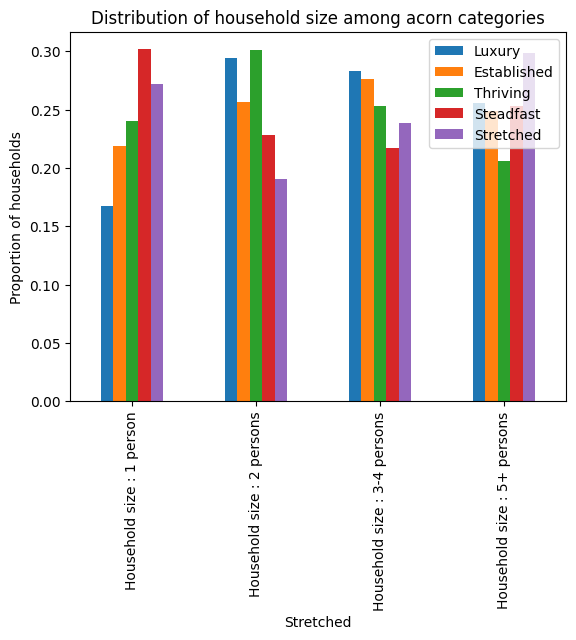

```python
plot_category_distribution(acorn_category_df, "Household Size", "Distribution of household size among acorn categories")
```

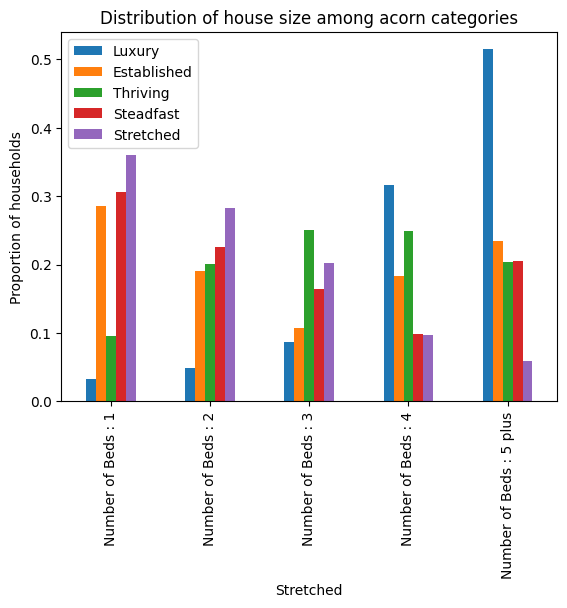

```python
plot_category_distribution(acorn_category_df, "House Size", "Distribution of house size among acorn categories")
```

#### **Hypothesis Test 1: Wilcoxon Signed-Rank Test for Difference in Energy Consumption by Household on Weekdays vs. Weekends**

Here, we get the average energy consumption for each household across all weekdays, and all weekends. We can pair these values by household, so we run the nonparametric version of a paired T-test, a Wilcoxon Signed-Rank test, on this data. We run the nonparametric version as the data doesn't indicate an underlying normal distribution for the population. The violin plot below shows that in the sample data we have, the average energy consumption per household is slightly higher on the weekends than on the weekdays, with both distributions heavily skewed towards the right.

We expect that the weekend will show a higher average energy consumption, as people are more likely to be at home on the weekends and using energy. So, we have the hypotheses:

H0: the true mean energy consumption of a household is the same on the weekend and the weekdays.

Ha: the true mean energy consumption of a household is greater on the weekend than the weekdays.

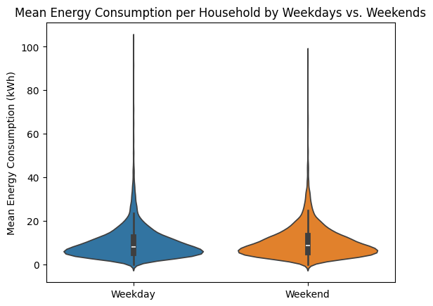

```python
daily_df['weekend'] = daily_df['date'].apply(lambda x: x.dayofweek > 4)
household_energy_consumption_by_weekday = daily_df.groupby(["LCLid", "weekend"])["energy_sum"].mean().reset_index()
household_energy_consumption_by_weekday = household_energy_consumption_by_weekday.drop(11116) # this specific household has no data for the weekends
weekday = household_energy_consumption_by_weekday[household_energy_consumption_by_weekday["weekend"] == False]["energy_sum"]
weekend = household_energy_consumption_by_weekday[household_energy_consumption_by_weekday["weekend"] == True]["energy_sum"]
fig = sns.violinplot([weekday.to_list(), weekend.to_list()])
fig.set_xticklabels(["Weekday", "Weekend"])
fig.set_ylabel("Mean Energy Consumption (kWh)")
fig.set_title("Mean Energy Consumption per Household by Weekdays vs. Weekends")
plt.show()
```

```python
stats.wilcoxon(weekday, weekend, alternative="less")
```

```
WilcoxonResult(statistic=3858574.0, pvalue=1.4358815427202813e-229)
```

Running the test gives a p-value very close to 0, which is less than our significance level of 0.05, so we reject the null hypothesis. There is sufficient evidence that the true mean energy consumption of a household is greater on the weekend than the weekdays.

#### **Hypothesis Test 2: Friedman Test for the Difference in Median Energy Consumption Between Seasons**

Another aspect of the data that we are interested in is checking whether or not there is a statistically significant difference in the median average daily energy consumption for a household between seasons. Understanding if the seasons affect energy consumption allow us to better predict energy consumption going into the future.

H0: the true median daily energy consumption per household is the same for all seasons.

Ha: the true median daily energy consumption per household differ for at least two of the seasons.

**Adding season to our dataframe**

```python
# Here, we add, for each row of data, the season that the data was recorded in.
# This is done using the get_season() function which takes in a date and converts it to
# the string "winter", "fall", "spring", or "summer".

def get_season(doy):
  spring = range(80, 172)
  summer = range(172, 264)
  fall = range(264, 355)

  if doy in spring:
    season = 'spring'
  elif doy in summer:
    season = 'summer'
  elif doy in fall:
    season = 'fall'
  else:
    season = 'winter'
  return season

daily_df["season"] = daily_df["date"].apply(lambda x: get_season(x.timetuple().tm_yday))

daily_df.head(15)
```

|  | LCLid | date | energy_median | energy_mean | energy_max | energy_count | energy_std | energy_sum | energy_min | Acorn_category | weekend | season |
| --- | --- | --- | --- | --- | --- | --- | --- | --- | --- | --- | --- | --- |
| 0 | MAC000131 | 2011-12-15 | 0.4850 | 0.432045 | 0.868 | 22 | 0.239146 | 9.505 | 0.072 | Established | False | fall |
| 1 | MAC000131 | 2011-12-16 | 0.1415 | 0.296167 | 1.116 | 48 | 0.281471 | 14.216 | 0.031 | Established | False | fall |
| 2 | MAC000131 | 2011-12-17 | 0.1015 | 0.189812 | 0.685 | 48 | 0.188405 | 9.111 | 0.064 | Established | True | fall |
| 3 | MAC000131 | 2011-12-18 | 0.1140 | 0.218979 | 0.676 | 48 | 0.202919 | 10.511 | 0.065 | Established | True | fall |
| 4 | MAC000131 | 2011-12-19 | 0.1910 | 0.325979 | 0.788 | 48 | 0.259205 | 15.647 | 0.066 | Established | False | fall |
| 5 | MAC000131 | 2011-12-20 | 0.2180 | 0.357500 | 1.077 | 48 | 0.287597 | 17.160 | 0.066 | Established | False | fall |
| 6 | MAC000131 | 2011-12-21 | 0.1305 | 0.235083 | 0.705 | 48 | 0.222070 | 11.284 | 0.066 | Established | False | winter |
| 7 | MAC000131 | 2011-12-22 | 0.0890 | 0.221354 | 1.094 | 48 | 0.267239 | 10.625 | 0.062 | Established | False | winter |
| 8 | MAC000131 | 2011-12-23 | 0.1605 | 0.291125 | 0.749 | 48 | 0.249076 | 13.974 | 0.065 | Established | False | winter |
| 9 | MAC000131 | 2011-12-24 | 0.1070 | 0.169000 | 0.613 | 47 | 0.150685 | 7.943 | 0.065 | Established | True | winter |
| 10 | MAC000131 | 2011-12-25 | 0.2175 | 0.339187 | 0.866 | 48 | 0.263101 | 16.281 | 0.069 | Established | True | winter |
| 11 | MAC000131 | 2011-12-26 | 0.1495 | 0.261708 | 0.838 | 48 | 0.244793 | 12.562 | 0.066 | Established | False | winter |
| 12 | MAC000131 | 2011-12-27 | 0.1430 | 0.274000 | 0.778 | 48 | 0.252127 | 13.152 | 0.068 | Established | False | winter |
| 13 | MAC000131 | 2011-12-28 | 0.1455 | 0.300521 | 1.207 | 48 | 0.298680 | 14.425 | 0.066 | Established | False | winter |
| 14 | MAC000131 | 2011-12-29 | 0.1520 | 0.307042 | 0.888 | 48 | 0.264455 | 14.738 | 0.066 | Established | False | winter |

**Dropping households without data for all seasons**

```python
filtered_daily_df = daily_df.groupby('LCLid').filter(lambda x: x['season'].nunique() == 4)
filtered_daily_df
```

|  | LCLid | date | energy_median | energy_mean | energy_max | energy_count | energy_std | energy_sum | energy_min | Acorn_category | weekend | season |
| --- | --- | --- | --- | --- | --- | --- | --- | --- | --- | --- | --- | --- |
| 0 | MAC000131 | 2011-12-15 | 0.4850 | 0.432045 | 0.868 | 22 | 0.239146 | 9.505 | 0.072 | Established | False | fall |
| 1 | MAC000131 | 2011-12-16 | 0.1415 | 0.296167 | 1.116 | 48 | 0.281471 | 14.216 | 0.031 | Established | False | fall |
| 2 | MAC000131 | 2011-12-17 | 0.1015 | 0.189812 | 0.685 | 48 | 0.188405 | 9.111 | 0.064 | Established | True | fall |
| 3 | MAC000131 | 2011-12-18 | 0.1140 | 0.218979 | 0.676 | 48 | 0.202919 | 10.511 | 0.065 | Established | True | fall |
| 4 | MAC000131 | 2011-12-19 | 0.1910 | 0.325979 | 0.788 | 48 | 0.259205 | 15.647 | 0.066 | Established | False | fall |
| ... | ... | ... | ... | ... | ... | ... | ... | ... | ... | ... | ... | ... |
| 3510427 | MAC004977 | 2014-02-23 | 0.1365 | 0.174646 | 0.754 | 48 | 0.151583 | 8.383 | 0.046 | Established | True | winter |
| 3510428 | MAC004977 | 2014-02-24 | 0.0950 | 0.118458 | 0.580 | 48 | 0.093814 | 5.686 | 0.052 | Established | False | winter |
| 3510429 | MAC004977 | 2014-02-25 | 0.0675 | 0.084208 | 0.176 | 48 | 0.037107 | 4.042 | 0.046 | Established | False | winter |
| 3510430 | MAC004977 | 2014-02-26 | 0.1080 | 0.120500 | 0.282 | 48 | 0.069332 | 5.784 | 0.046 | Established | False | winter |
| 3510431 | MAC004977 | 2014-02-27 | 0.0720 | 0.114062 | 0.431 | 48 | 0.094482 | 5.475 | 0.047 | Established | False | winter |

3491025 rows × 12 columns

**Grouping the data for the hypothesis test**

```python
household_energy_consumption_by_season = filtered_daily_df.groupby(["LCLid", "season"])["energy_sum"].mean().reset_index()

fall = household_energy_consumption_by_season[household_energy_consumption_by_season["season"] == "fall"]["energy_sum"]
spring = household_energy_consumption_by_season[household_energy_consumption_by_season["season"] == "spring"]["energy_sum"]
summer = household_energy_consumption_by_season[household_energy_consumption_by_season["season"] == "summer"]["energy_sum"]
winter = household_energy_consumption_by_season[household_energy_consumption_by_season["season"] == "winter"]["energy_sum"]

print(f"Fall: {fall.shape}")
print(f"Spring: {spring.shape}")
print(f"Summer: {summer.shape}")
print(f"Winter: {winter.shape}")
```

```
Fall: (5512,)
Spring: (5512,)
Summer: (5512,)
Winter: (5512,)
```

**Run Friedman test**

```python
stats.friedmanchisquare(fall, spring, summer, winter)
```

```
FriedmanchisquareResult(statistic=7742.841469168515, pvalue=0.0)
```

The p-value is 0.0, which is less than our chosen significance level of 0.05, so we reject the null hypothesis. At least two of the seasons have a statistically significant difference in true median average daily energy consumption.

**Post hoc tests**

```python
p_values = sp.posthoc_dunn([fall, spring, summer, winter], p_adjust = 'holm')
p_values
```

|  | 1 | 2 | 3 | 4 |
| --- | --- | --- | --- | --- |
| 1 | 1.000000e+00 | 1.659800e-18 | 1.026756e-71 | 8.770543e-08 |
| 2 | 1.659800e-18 | 1.000000e+00 | 1.853663e-19 | 3.342623e-45 |
| 3 | 1.026756e-71 | 1.853663e-19 | 1.000000e+00 | 8.747190e-120 |
| 4 | 8.770543e-08 | 3.342623e-45 | 8.747190e-120 | 1.000000e+00 |

```python
sign_table = sp.sign_table(p_values)
sign_table
```

|  | 1 | 2 | 3 | 4 |
| --- | --- | --- | --- | --- |
| 1 | - | *** | *** | *** |
| 2 | *** | - | *** | *** |
| 3 | *** | *** | - | *** |
| 4 | *** | *** | *** | - |

Here, we ran the post hoc test for our Friedman test (which is Dunn's Test). We see that the p - value between different seasons are completely different and very close to 0, which shows that for all pairs of seasons, there is no similarity in the true median average daily energy consumption. We can see from the following visualization why this might be the case.

We know that in the UK, the daily average temperature varies with season. From the below visualization, we see that average total energy consumption for a household is strongly negatively correlated with temperature. Thus, this visualization provides a good understanding of why we reject the null hypothesis -- because seasons have different average temperatures, and temperature is strongly correlated with energy consumption.

```python
daily_average_energy = pd.DataFrame(daily_df.groupby("date")["energy_sum"].mean()).reset_index()
daily_average_temperature = pd.DataFrame(weather_df.groupby("date")["temperatureAverage"].mean()).reset_index()

daily_average_temperature["date"] = pd.to_datetime(daily_average_temperature["date"])

print(daily_average_energy.head())
print(daily_average_temperature.head())
```

```
        date  energy_sum
0 2011-11-23    6.952692
1 2011-11-24    8.536480
2 2011-11-25    9.499781
3 2011-11-26   10.267707
4 2011-11-27   10.850805
        date  temperatureAverage
0 2011-11-01              12.225
1 2011-11-02              14.525
2 2011-11-03              14.965
3 2011-11-04              12.855
4 2011-11-05              11.700
```

```python
daily_energy_and_temperature = daily_average_energy.merge(daily_average_temperature, left_on = "date", right_on = "date")
daily_energy_and_temperature.head()
```

|  | date | energy_sum | temperatureAverage |
| --- | --- | --- | --- |
| 0 | 2011-11-23 | 6.952692 | 9.300 |
| 1 | 2011-11-24 | 8.536480 | 11.320 |
| 2 | 2011-11-25 | 9.499781 | 9.640 |
| 3 | 2011-11-26 | 10.267707 | 12.275 |
| 4 | 2011-11-27 | 10.850805 | 7.425 |

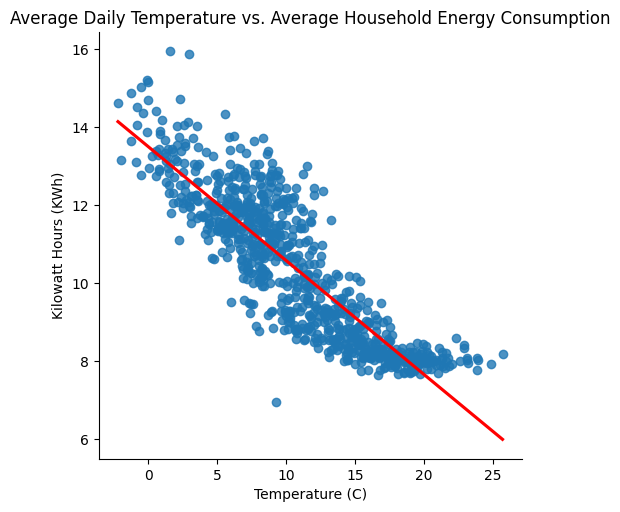

```python
import seaborn as sns

# Create the scatter plot with a regression line and set the line color
sns.lmplot(x="temperatureAverage", y="energy_sum", data=daily_energy_and_temperature, ci=None,
           line_kws={'color': 'red'})  # You can change 'red' to any color you prefer

# Add title and labels
plt.title("Average Daily Temperature vs. Average Household Energy Consumption")
plt.xlabel("Temperature (C)")
plt.ylabel("Kilowatt Hours (KWh)")

plt.show()
```

```python
correlation_matrix = daily_energy_and_temperature[["energy_sum", "temperatureAverage"]].corr()
print(correlation_matrix)
```

```
                    energy_sum  temperatureAverage
energy_sum            1.000000           -0.869429
temperatureAverage   -0.869429            1.000000
```

Additionally, as a further indication of seasonality, we also performed some spectrum anaylsis on the daily energy consumption data. To do this, we created a periodogram for the data.

However, as a caveat, since our data only spans about 2-3 years, the confidence of our results may not be the best. Either way, we thought that including this would be interesting.

As context, a periodogram is a visualization that shows the spectral density of range of frequencies. If there is a peak at a certain frequency, we can take the reciprocal of it to see the size of the dominant cycle. If the dominant cycle is around a year, which in this case is 365, there is a good chance that the data can be viewed as having yearly cycles.

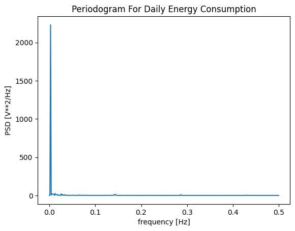

```python
two_year_df = daily_df[
  (daily_df["date"] >= datetime(month=1, day=1, year=2012)) &
  (daily_df["date"] < datetime(month=1, day=1, year=2014))
]

f, Pxx = periodogram(two_year_df.groupby("date")["energy_sum"].mean())

plt.figure()
plt.plot(f, Pxx)
plt.xlabel('frequency [Hz]')
plt.ylabel('PSD [V**2/Hz]')
plt.title('Periodogram For Daily Energy Consumption')
plt.show()
```

Here, we see a peek in the periodogram, indicating a dominant frequency.

```python
Pxx.tolist()[:10]
```

```
[4.8501456257528254e-29,
 7.226547749176437,
 2230.1090415913723,
 3.075438333006837,
 20.852283414426253,
 17.846620448164796,
 16.529932738248377,
 15.250836869437132,
 1.3835518736254544,
 26.063783493986836]
```

```python
f.tolist()[:10]
```

```
[0.0,
 0.0013679890560875513,
 0.0027359781121751026,
 0.004103967168262654,
 0.005471956224350205,
 0.006839945280437756,
 0.008207934336525308,
 0.009575923392612859,
 0.01094391244870041,
 0.012311901504787962]
```

We see that the most dominant frequency is in the 3rd element of the list

```python
1/f.tolist()[2]
```

```
365.5
```

Now, after some calculations, we can see that the most dominant frequency indicates a periodicity of about a year, which reinforces that the data is likely seasonal.

As another supplemental analysis, we also performed seasonal decomposition.

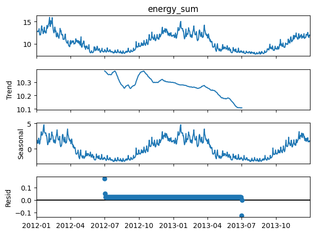

```python
res = sm.tsa.seasonal_decompose(two_year_df.groupby("date")["energy_sum"].mean(), period=365)
res.plot()
plt.show()
```

Here, we see that the seasonal portion of the decomposition follows much of the trends of the original data, thus providing a positive indicator that the data is seasonal.

#### **Test 3: Kruskal-Wallis Test For Difference In Median Energy Consumption Between ACORNS**

Another aspect of the data that we are interested in is checking whether or not there is a statistically significant difference in the median average daily energy consumption for a household between acorn groups. Understanding if the acorn group affects energy consumption will also allow us to better predict energy consumption going into the future.

H0: the true median daily energy consumption per household is the same for all acorn groups.

Ha: the true median daily energy consumption per household differ for at least two of the acorn groups.

**Gather necessary data for the test**

```python
acorns = ["Low Income", "Stretched", "Steadfast", "Thriving", "Established", "Luxury"]
household_energy_consumption_by_acorn = daily_df.groupby(["LCLid", "Acorn_category"])["energy_sum"].mean().reset_index()

acorn_means = []

for acorn in acorns:
  sample = household_energy_consumption_by_acorn[household_energy_consumption_by_acorn["Acorn_category"] == acorn]["energy_sum"]
  acorn_means.append(sample)

for acorn, means in zip(acorns, acorn_means):
  print(f"{acorn}: {means.shape}")
```

```
Low Income: (49,)
Stretched: (938,)
Steadfast: (875,)
Thriving: (1505,)
Established: (1859,)
Luxury: (333,)
```

**Visualize distribution of energy sum per household by Acorn group**

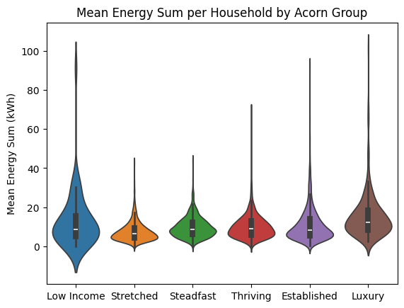

```python
fig = sns.violinplot([s.to_list() for s in acorn_means])
fig.set_xticklabels(acorns)
fig.set_ylabel("Mean Energy Sum (kWh)")
fig.set_title("Mean Energy Sum per Household by Acorn Group")
plt.show()
```

**Run the test**

```python
stats.kruskal(*acorn_means)
```

```
KruskalResult(statistic=329.43697054085715, pvalue=4.667635463114512e-69)
```

The p-value is very close to 0, which is less than our chosen significance level of 0.05, so we reject the null hypothesis. At least two of the acorns groups have a statistically significant difference in true median average daily energy consumption.

**Post hoc tests**

```python
p_values = sp.posthoc_dunn(acorn_means, p_adjust='holm')
p_values
```

|  | 1 | 2 | 3 | 4 | 5 | 6 |
| --- | --- | --- | --- | --- | --- | --- |
| 1 | 1.000000 | 4.735542e-03 | 1.000000e+00 | 1.000000e+00 | 1.000000e+00 | 1.382068e-03 |
| 2 | 0.004736 | 1.000000e+00 | 3.831102e-26 | 7.915818e-34 | 1.483883e-31 | 2.744578e-62 |
| 3 | 1.000000 | 3.831102e-26 | 1.000000e+00 | 1.000000e+00 | 1.000000e+00 | 1.575579e-17 |
| 4 | 1.000000 | 7.915818e-34 | 1.000000e+00 | 1.000000e+00 | 1.000000e+00 | 2.494202e-19 |
| 5 | 1.000000 | 1.483883e-31 | 1.000000e+00 | 1.000000e+00 | 1.000000e+00 | 1.419967e-22 |
| 6 | 0.001382 | 2.744578e-62 | 1.575579e-17 | 2.494202e-19 | 1.419967e-22 | 1.000000e+00 |

```python
print("-----Key-----")
for i, acorn in enumerate(acorns):
  print(f"{i+1}: {acorn}")
```

```
-----Key-----
1: Low Income
2: Stretched
3: Steadfast
4: Thriving
5: Established
6: Luxury
```

```python
sign_table = sp.sign_table(p_values)
sign_table
```

|  | 1 | 2 | 3 | 4 | 5 | 6 |
| --- | --- | --- | --- | --- | --- | --- |
| 1 | - | ** | NS | NS | NS | ** |
| 2 | ** | - | *** | *** | *** | *** |
| 3 | NS | *** | - | NS | NS | *** |
| 4 | NS | *** | NS | - | NS | *** |
| 5 | NS | *** | NS | NS | - | *** |
| 6 | ** | *** | *** | *** | *** | - |

Here, we ran the post hoc test for Kruskal Wallis (which is Dunn's Test). As context, in the sign table, a `*`, `**`, or `***` represents a statistically significant pairing while `NS` represents a pairing that is not statistically different.

We can see in the sign table that there about half of the pairings are statistically significant while the other half are not. Overall, though, this does showcase that different Acorn groups have different median average daily energy consumptions. The below visualization provides more visual evidence for this finding, as well.

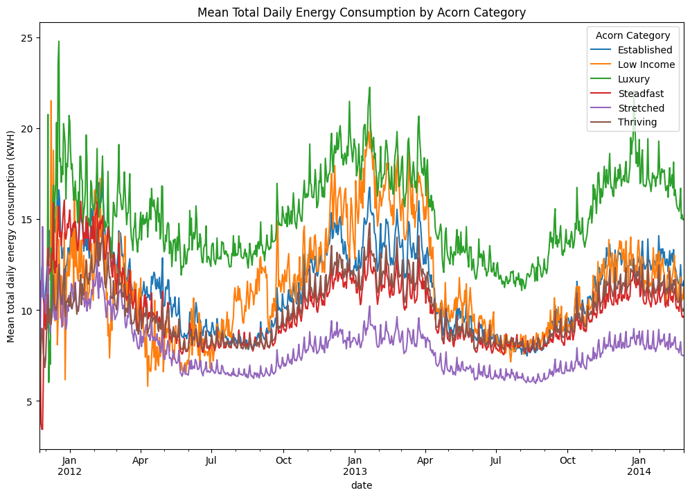

```python
fig, ax = plt.subplots(figsize=(12, 8))

energy_sum = daily_df.groupby(['Acorn_category', 'date'])['energy_sum'].mean().reset_index()
energy_sum = energy_sum[energy_sum['Acorn_category'] != "No Category"]
energy_sum

for name, group in energy_sum.groupby('Acorn_category'):
    group.plot(x='date', y='energy_sum', ax=ax, label=name)

plt.ylabel('Mean total daily energy consumption (KWH)')
plt.title('Mean Total Daily Energy Consumption by Acorn Category')
plt.legend(title='Acorn Category')

plt.show()
```

This graph shows the mean daily total energy consumption for each acorn category between 2011 and 2014. On average, households in the Luxury category have the highest energy consumption while households in the Stretched category have the lowest energy consumption levels. While the energy consumption levels are sequentially lower from higher to lower income households, the Low Income category has the second highest energy consumption levels between August 2012 and April 2013 after the Luxury category. All of the lines also show an increasing in energy consumption during the winter months between December and February and a decrease in energy consumption during the summer months between June and September. This makes sense because most England households do not have AC so their energy usage would increase during the winter when they need heating.

#### **Supplemental Test: ADF Stationary Test For Acorn Groups**

As some supplemental analysis, we also performed ADF tests for each acorn for daily energy consumption in order to inform us if the data is stationary or not for each acorn. This could serve as useful information when choosing our forecasting model in the future since stationary data is either mandatory or recommended for some models.

The hypotheses for each acorn are below.

H0: a unit root is present in the time series data for average daily consumption for the specified acorn type

Ha: the time series data has no unit root, meaning that the data is stationary for the specified acorn type

```python
def perform_tests(df):
  average_df = df.groupby("date")[["energy_sum"]].mean()
  pvalues = []
  series = average_df["energy_sum"]
  pvalue = np.NaN if np.all(series == series.iloc[0]) else adfuller(series)[1]
  pvalues.append(pvalue)
  return pvalues

acorn_dfs = daily_df.groupby("Acorn_category")[["energy_sum", "date"]]
adf_df = pd.DataFrame(columns=["energy_sum"])
for acorn, acorn_subset_df in acorn_dfs:
  pvalues = perform_tests(acorn_subset_df)
  adf_df.loc[acorn] = pvalues
adf_df
```

|  | energy_sum |
| --- | --- |
| Established | 0.229401 |
| Low Income | 0.372457 |
| Luxury | 0.233889 |
| No Category | 0.326184 |
| Steadfast | 0.084336 |
| Stretched | 0.285624 |
| Thriving | 0.261185 |

Here, we see that for each acorn, the p-value is greater than 0.05, indicating that we fail to reject the null hypothesis for each acorn group, meaning that the data for all acorn groups is not stationary.

### **ML & Primary Analysis**

To recap the above findings, we have determined that

- Average daily energy usage is greater on weekends than weekdays
- Average daily energy usage is different for each season, following a yearly seasonal trend due to cyclic factors such as temperature
- Avarage daily energy usage is different amongst acorn groups
- Average daily energy usage is not stationary for our dataset

Given these findings, as well as the fact that we intend to forecast daily energy usage, which is a continuous variable, we can determine that we need to utilize a regression model that works well on non-stationary seasonal datasets.

Since the dataset is not stationary, we can't necessarily utilize ARIMA or SARIMA, which are popular seasonal models, (at least optimally) with the dataset as is.

Other models exist though that don't require this requirement.

The two that we chose for our tutorial are

1. PROPHET
2. LSTM

First, the PROPHET model is a statistical model that works very well for seasonal data, and unlike ARIMA or SARIMA, it does not require stationary data.

To account for spikes for weekends that we observed above, we can also attach a boolean integer variable `is_weekend` to the model as a additional regressor.

Second, LSTM is a type of RNN model that can be used for timeseries forecasting. The model is certainly more complicated than PROPHET and requires more feature engineering and hyperparameter tuning. However, due to the fluctuations that occur on top of the yearly seasonality, we thought that it is at least worth a try.

As an important note before we continue to the models, since there is a difference in average energy usage between acorn groups as described above, we chose for the sake of the tutorial to train the models on an average of all of the daily energy usages for the acorn group `Established` (basically bucketing all of the data for this acorn to daily buckets then averaging those). The implementation will be done below whenever we prepare our model data.

#### **PROPHET Model**

**Imports**

```python
from prophet import Prophet
```

**Preparing Data**

As hinted at above, the PROPHET model will forecast `y = energy_sum` with an additional regressor in `is_weekend`.

```python
sample_df = daily_df[daily_df["Acorn_category"] == "Established"]
sample_df = sample_df.drop(columns="LCLid")
sample_df = sample_df.groupby("date")["energy_sum"].mean().reset_index()
sample_df["is_weekend"] = pd.to_datetime(sample_df["date"]).apply(lambda x: int(x.dayofweek > 4))
prophet_df = sample_df[['date', 'energy_sum']].rename(columns={'date': 'ds', 'energy_sum': 'y'})
prophet_df['is_weekend'] = sample_df['is_weekend']
prophet_df
```

|  | ds | y | is_weekend |
| --- | --- | --- | --- |
| 0 | 2011-11-23 | 11.551500 | 0 |
| 1 | 2011-11-24 | 10.654900 | 0 |
| 2 | 2011-11-25 | 11.062214 | 0 |
| 3 | 2011-11-26 | 12.207176 | 1 |
| 4 | 2011-11-27 | 12.611000 | 1 |
| ... | ... | ... | ... |
| 823 | 2014-02-23 | 12.498105 | 1 |
| 824 | 2014-02-24 | 11.507970 | 0 |
| 825 | 2014-02-25 | 11.384361 | 0 |
| 826 | 2014-02-26 | 11.314600 | 0 |
| 827 | 2014-02-27 | 11.590049 | 0 |

828 rows × 3 columns

**Defining The Model**

```python
prophet_model = Prophet(yearly_seasonality=True)
prophet_model.add_regressor('is_weekend')
```

```
<prophet.forecaster.Prophet at 0x795ffdb74d30>
```

**Fitting Model**

```python
prophet_model.fit(prophet_df)
```

[output not shown]

```
<prophet.forecaster.Prophet at 0x795ffdb74d30>
```

As a small note, the fitting took only about a few seconds, which makes sense since PROPHET is considered a "fast" model.

**Forecasting 1 Year Into The Future**

```python
future_df = prophet_model.make_future_dataframe(periods=365)
future_df['is_weekend'] = pd.concat([prophet_df['is_weekend'], prophet_df['is_weekend'].iloc[-365:].reset_index(drop=True)], ignore_index=True)
forecast = prophet_model.predict(future_df)
forecast[['ds', 'yhat', 'yhat_lower', 'yhat_upper']].tail()
```

|  | ds | yhat | yhat_lower | yhat_upper |
| --- | --- | --- | --- | --- |
| 1188 | 2015-02-23 | 9.832496 | 8.763558 | 10.894891 |
| 1189 | 2015-02-24 | 9.681890 | 8.624276 | 10.749722 |
| 1190 | 2015-02-25 | 9.579834 | 8.521051 | 10.653070 |
| 1191 | 2015-02-26 | 9.433292 | 8.345138 | 10.482018 |
| 1192 | 2015-02-27 | 9.411713 | 8.291956 | 10.475487 |

**Plotting The Forecast**

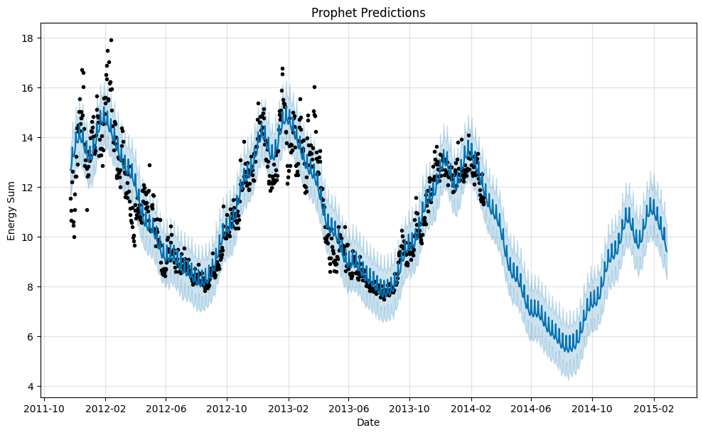

```python
prophet_model.plot(forecast)
plt.title("Prophet Predictions")
plt.xlabel("Date")
plt.ylabel("Energy Sum")
plt.show()
```

As you can see in the plot, the PROPHET model in its forecasting is practically mimicking the aforementioned loops while decreasing the overall peak of these cycles, which has been shown in the original dataset. Whether or not that assumption is correct is up to debate, but given the limited data we have, this seems like a pretty good forecast overall.

Now, let's repeat the process but with a train test split.

**Train Test Split**

```python
train_size = int(len(prophet_df) * 0.7)
train_df = prophet_df.iloc[:train_size]
test_df = prophet_df.iloc[train_size:]
```

**Defining The Model Again**

```python
prophet_model = Prophet(yearly_seasonality=True)
prophet_model.add_regressor('is_weekend')
```

```
<prophet.forecaster.Prophet at 0x795febc9fdc0>
```

**Fitting Model With Train Set**

```python
prophet_model.fit(train_df)
```

[output not shown]

```
<prophet.forecaster.Prophet at 0x795febc9fdc0>
```

**Forecasting The Test Set**

```python
future_df = prophet_model.make_future_dataframe(periods=len(test_df), freq='D')
future_df['is_weekend'] = pd.concat([train_df['is_weekend'], test_df['is_weekend'].reset_index(drop=True)], ignore_index=True)
forecast = prophet_model.predict(future_df)
forecast[['ds', 'yhat', 'yhat_lower', 'yhat_upper']].tail()
```

|  | ds | yhat | yhat_lower | yhat_upper |
| --- | --- | --- | --- | --- |
| 823 | 2014-02-23 | 13.765137 | 12.603072 | 14.866103 |
| 824 | 2014-02-24 | 13.201644 | 12.161949 | 14.286106 |
| 825 | 2014-02-25 | 13.026682 | 11.919114 | 14.130919 |
| 826 | 2014-02-26 | 12.907371 | 11.806505 | 14.052467 |
| 827 | 2014-02-27 | 12.765010 | 11.615158 | 13.840623 |

**Plotting The Forecast**

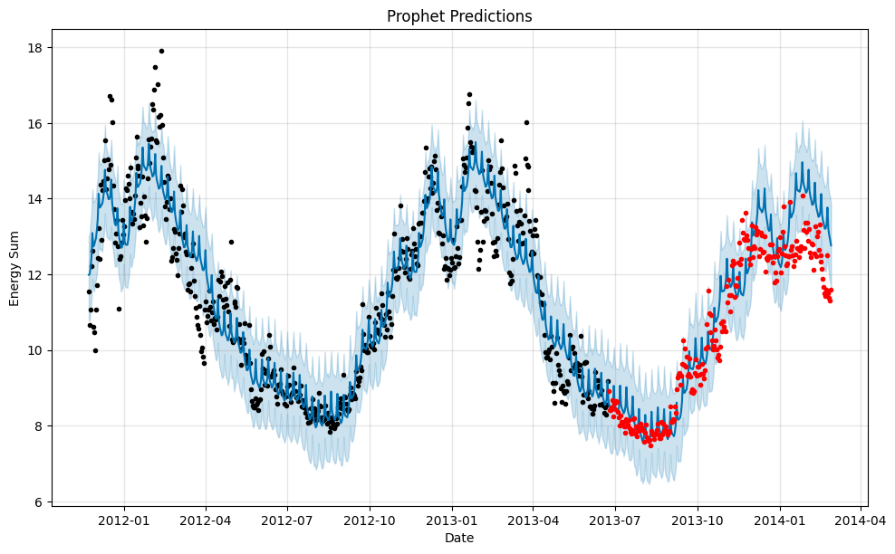

```python
prophet_model.plot(forecast)
test_dates = test_df['ds']
test_values = test_df['y']
plt.plot(test_dates, test_values, 'r.', label='Test Y Values')
plt.title("Prophet Predictions")
plt.xlabel("Date")
plt.ylabel("Energy Sum")
plt.show()
```

We can see here that the prophet model is sort of "overshooting" the test values, which could be due to a lack of data that provided context in the previous iteration of the model that took the entire dataset.

**Performance Metrics for Prophet**

To calculate the performance of the Prophet model, we use their built in `cross_validation` and `performance_metrics` functions.

```python
from prophet.diagnostics import cross_validation
df_cv = cross_validation(prophet_model, initial='500 days', period='180 days', horizon = '20 days')
```

```
INFO:prophet:Making 1 forecasts with cutoffs between 2013-06-03 00:00:00 and 2013-06-03 00:00:00
```

[output not shown]

```python
from prophet.diagnostics import performance_metrics
df_p = performance_metrics(df_cv)
df_p.head()
```

|  | horizon | mse | rmse | mae | mape | mdape | smape | coverage |
| --- | --- | --- | --- | --- | --- | --- | --- | --- |
| 0 | 2 days | 0.301853 | 0.549411 | 0.549300 | 0.064696 | 0.064696 | 0.062668 | 1.0 |
| 1 | 3 days | 0.362206 | 0.601835 | 0.600496 | 0.071579 | 0.071579 | 0.069092 | 1.0 |
| 2 | 4 days | 0.394501 | 0.628093 | 0.627966 | 0.074935 | 0.074935 | 0.072227 | 1.0 |
| 3 | 5 days | 0.425300 | 0.652150 | 0.651164 | 0.076761 | 0.076761 | 0.073917 | 1.0 |
| 4 | 6 days | 0.285266 | 0.534103 | 0.500465 | 0.056954 | 0.056954 | 0.055120 | 1.0 |

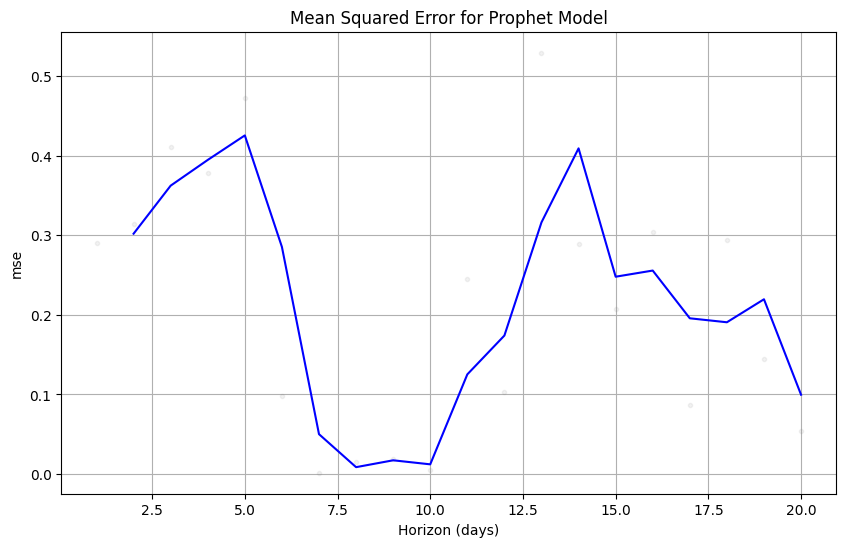

```python
from prophet.plot import plot_cross_validation_metric
fig = plot_cross_validation_metric(df_cv, metric='mse')
plt.title('Mean Squared Error for Prophet Model')
plt.show()
```

All of the MSE values are below 0.5 which shows that the model is performing pretty well, despite it overshooting.

#### **LSTM**

**Imports**

```python
from tensorflow.keras.models import Sequential
from tensorflow.keras.layers import LSTM, Dense, Dropout
from tensorflow.keras.regularizers import l2
from sklearn.preprocessing import MinMaxScaler
from sklearn.model_selection import train_test_split
```

**Preparing Data**

As mentioned above, LSTM models are generally more complex than PROPHET models, which requires us to take more effort in selecting our features and hyperparameters.

To start, of course, the prediction variable `y` will be `energy_sum`.

So yeah, let's go ahead and get that data first.

```python
sample_df = daily_df[daily_df["Acorn_category"] == "Established"]
sample_df = sample_df.drop(columns="LCLid")
sample_df = sample_df.groupby("date")["energy_sum"].mean().reset_index()
sample_df
```

|  | date | energy_sum |
| --- | --- | --- |
| 0 | 2011-11-23 | 11.551500 |
| 1 | 2011-11-24 | 10.654900 |
| 2 | 2011-11-25 | 11.062214 |
| 3 | 2011-11-26 | 12.207176 |
| 4 | 2011-11-27 | 12.611000 |
| ... | ... | ... |
| 823 | 2014-02-23 | 12.498105 |
| 824 | 2014-02-24 | 11.507970 |
| 825 | 2014-02-25 | 11.384361 |
| 826 | 2014-02-26 | 11.314600 |
| 827 | 2014-02-27 | 11.590049 |

828 rows × 2 columns

In terms of our features, since we know that there is yearly seasonality in our data, we can do a sine and cosine transform on the day of year.

Our motive for doing this is that it would make data points and the start and end of the year be considered closer together, which would not be the case if we simply did day of year (start would be 1 and end would be 365).

```python
sample_df['day_of_year'] = sample_df['date'].dt.dayofyear
sample_df['sin_day'] = np.sin(2 * np.pi * sample_df['day_of_year'] / 365)
sample_df['cos_day'] = np.cos(2 * np.pi * sample_df['day_of_year'] / 365)
sample_df = sample_df.drop(columns="day_of_year")
sample_df
```

|  | date | energy_sum | sin_day | cos_day |
| --- | --- | --- | --- | --- |
| 0 | 2011-11-23 | 11.551500 | -0.608477 | 0.793572 |
| 1 | 2011-11-24 | 10.654900 | -0.594727 | 0.803928 |
| 2 | 2011-11-25 | 11.062214 | -0.580800 | 0.814046 |
| 3 | 2011-11-26 | 12.207176 | -0.566702 | 0.823923 |
| 4 | 2011-11-27 | 12.611000 | -0.552435 | 0.833556 |
| ... | ... | ... | ... | ... |
| 823 | 2014-02-23 | 12.498105 | 0.801361 | 0.598181 |
| 824 | 2014-02-24 | 11.507970 | 0.811539 | 0.584298 |
| 825 | 2014-02-25 | 11.384361 | 0.821477 | 0.570242 |
| 826 | 2014-02-26 | 11.314600 | 0.831171 | 0.556017 |
| 827 | 2014-02-27 | 11.590049 | 0.840618 | 0.541628 |

828 rows × 4 columns

We also chose to add a sine and cosine transform on day of week as well as keep a boolean `is_weekend` feature.

```python
sample_df['day_of_week'] = sample_df['date'].dt.dayofweek
sample_df["is_weekend"] = sample_df["date"].apply(lambda x: int(x.dayofweek > 4))
sample_df['sin_day_of_week'] = np.sin(2 * np.pi * sample_df['day_of_week'] / 7)
sample_df['cos_day_of_week'] = np.cos(2 * np.pi * sample_df['day_of_week'] / 7)
sample_df = sample_df.drop(columns="day_of_week")
sample_df
```

|  | date | energy_sum | sin_day | cos_day | is_weekend | sin_day_of_week | cos_day_of_week |
| --- | --- | --- | --- | --- | --- | --- | --- |
| 0 | 2011-11-23 | 11.551500 | -0.608477 | 0.793572 | 0 | 0.974928 | -0.222521 |
| 1 | 2011-11-24 | 10.654900 | -0.594727 | 0.803928 | 0 | 0.433884 | -0.900969 |
| 2 | 2011-11-25 | 11.062214 | -0.580800 | 0.814046 | 0 | -0.433884 | -0.900969 |
| 3 | 2011-11-26 | 12.207176 | -0.566702 | 0.823923 | 1 | -0.974928 | -0.222521 |
| 4 | 2011-11-27 | 12.611000 | -0.552435 | 0.833556 | 1 | -0.781831 | 0.623490 |
| ... | ... | ... | ... | ... | ... | ... | ... |
| 823 | 2014-02-23 | 12.498105 | 0.801361 | 0.598181 | 1 | -0.781831 | 0.623490 |
| 824 | 2014-02-24 | 11.507970 | 0.811539 | 0.584298 | 0 | 0.000000 | 1.000000 |
| 825 | 2014-02-25 | 11.384361 | 0.821477 | 0.570242 | 0 | 0.781831 | 0.623490 |
| 826 | 2014-02-26 | 11.314600 | 0.831171 | 0.556017 | 0 | 0.974928 | -0.222521 |
| 827 | 2014-02-27 | 11.590049 | 0.840618 | 0.541628 | 0 | 0.433884 | -0.900969 |

828 rows × 7 columns

The reason for this is because we noticed that there are also fluctuations in energy over the week with clear peaks during the weekend, as seen in the below plot

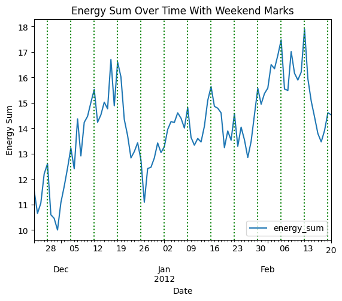

```python
import matplotlib.dates as mdates

sample_df = pd.merge(left = sample_df, right = weather_df[["date", "temperatureAverage"]], left_on = "date", right_on = "date")
sample_df
min_temp, max_temp = sample_df["temperatureAverage"].min(), sample_df["temperatureAverage"].max()
sample_df['day_of_week'] = sample_df['date'].dt.dayofweek
saturdays = sample_df[sample_df["day_of_week"] == 6]["date"].reset_index().drop(columns=["index"])
sample_df = sample_df.drop(columns="day_of_week")
saturdays = saturdays[saturdays["date"] < "2012-02-20"]
fig, ax = plt.subplots()
sample_df[:90].plot("date", "energy_sum", ax=ax)
ax.xaxis_date()
saturdays_numeric = mdates.date2num(saturdays)
for saturday in saturdays_numeric:
    ax.axvline(x=saturday[0], color='g', linestyle='dotted')
plt.title("Energy Sum Over Time With Weekend Marks")
plt.xlabel("Date")
plt.ylabel("Energy Sum")
plt.show()
```

Also, since our data is slightly decreasing per season, we also added a linear `time_since_start` feature.

```python
sample_df['time_since_start'] = (sample_df['date'] - sample_df['date'].min()).dt.days
sample_df
```

|  | date | energy_sum | sin_day | cos_day | is_weekend | sin_day_of_week | cos_day_of_week | temperatureAverage | time_since_start |
| --- | --- | --- | --- | --- | --- | --- | --- | --- | --- |
| 0 | 2011-11-23 | 11.551500 | -0.608477 | 0.793572 | 0 | 0.974928 | -0.222521 | 9.300 | 0 |
| 1 | 2011-11-24 | 10.654900 | -0.594727 | 0.803928 | 0 | 0.433884 | -0.900969 | 11.320 | 1 |
| 2 | 2011-11-25 | 11.062214 | -0.580800 | 0.814046 | 0 | -0.433884 | -0.900969 | 9.640 | 2 |
| 3 | 2011-11-26 | 12.207176 | -0.566702 | 0.823923 | 1 | -0.974928 | -0.222521 | 12.275 | 3 |
| 4 | 2011-11-27 | 12.611000 | -0.552435 | 0.833556 | 1 | -0.781831 | 0.623490 | 7.425 | 4 |
| ... | ... | ... | ... | ... | ... | ... | ... | ... | ... |
| 823 | 2014-02-23 | 12.498105 | 0.801361 | 0.598181 | 1 | -0.781831 | 0.623490 | 9.965 | 823 |
| 824 | 2014-02-24 | 11.507970 | 0.811539 | 0.584298 | 0 | 0.000000 | 1.000000 | 11.240 | 824 |
| 825 | 2014-02-25 | 11.384361 | 0.821477 | 0.570242 | 0 | 0.781831 | 0.623490 | 7.240 | 825 |
| 826 | 2014-02-26 | 11.314600 | 0.831171 | 0.556017 | 0 | 0.974928 | -0.222521 | 8.650 | 826 |
| 827 | 2014-02-27 | 11.590049 | 0.840618 | 0.541628 | 0 | 0.433884 | -0.900969 | 6.870 | 827 |

828 rows × 9 columns

Also, since albeit temperature is mostly seasonal, there will naturally be noise within the temperature over time. And since it is clear that temperature does affect energy usage, we chose to also add a `temperatureAverage` feature.

```python
sample_df = pd.merge(left = sample_df, right = weather_df[["date", "temperatureAverage"]], left_on = "date", right_on = "date")
sample_df
```

|  | date | energy_sum | sin_day | cos_day | is_weekend | sin_day_of_week | cos_day_of_week | temperatureAverage_x | time_since_start | temperatureAverage_y |
| --- | --- | --- | --- | --- | --- | --- | --- | --- | --- | --- |
| 0 | 2011-11-23 | 11.551500 | -0.608477 | 0.793572 | 0 | 0.974928 | -0.222521 | 9.300 | 0 | 9.300 |
| 1 | 2011-11-24 | 10.654900 | -0.594727 | 0.803928 | 0 | 0.433884 | -0.900969 | 11.320 | 1 | 11.320 |
| 2 | 2011-11-25 | 11.062214 | -0.580800 | 0.814046 | 0 | -0.433884 | -0.900969 | 9.640 | 2 | 9.640 |
| 3 | 2011-11-26 | 12.207176 | -0.566702 | 0.823923 | 1 | -0.974928 | -0.222521 | 12.275 | 3 | 12.275 |
| 4 | 2011-11-27 | 12.611000 | -0.552435 | 0.833556 | 1 | -0.781831 | 0.623490 | 7.425 | 4 | 7.425 |
| ... | ... | ... | ... | ... | ... | ... | ... | ... | ... | ... |
| 823 | 2014-02-23 | 12.498105 | 0.801361 | 0.598181 | 1 | -0.781831 | 0.623490 | 9.965 | 823 | 9.965 |
| 824 | 2014-02-24 | 11.507970 | 0.811539 | 0.584298 | 0 | 0.000000 | 1.000000 | 11.240 | 824 | 11.240 |
| 825 | 2014-02-25 | 11.384361 | 0.821477 | 0.570242 | 0 | 0.781831 | 0.623490 | 7.240 | 825 | 7.240 |
| 826 | 2014-02-26 | 11.314600 | 0.831171 | 0.556017 | 0 | 0.974928 | -0.222521 | 8.650 | 826 | 8.650 |
| 827 | 2014-02-27 | 11.590049 | 0.840618 | 0.541628 | 0 | 0.433884 | -0.900969 | 6.870 | 827 | 6.870 |

828 rows × 10 columns

Now let's see if there is any missing data.

```python
sample_df.isna().sum()
```

|  | 0 |
| --- | --- |
| date | 0 |
| energy_sum | 0 |
| sin_day | 0 |
| cos_day | 0 |
| is_weekend | 0 |
| sin_day_of_week | 0 |
| cos_day_of_week | 0 |
| temperatureAverage_x | 0 |
| time_since_start | 0 |
| temperatureAverage_y | 0 |

**dtype:** int64

There seems to be no missing data, which is great.

**Train Test Split**

We chose a 70-30 train test split for this tutorial.

```python
dataset = sample_df.drop(columns=["date"])

train_size = int(len(dataset) * 0.7)
dataset_train, dataset_test = dataset[:train_size], dataset[train_size:]
```

**Scaling Dataset**

Since we are using LSTM, we should also scale our data. In our case, we chose to use MinMaxScaling.

```python
scaler = MinMaxScaler()
dataset_train = scaler.fit_transform(dataset_train)
dataset_test = scaler.transform(dataset_test)
```

**Defining X and Y**

For our X, we want a lagged list of our target variable as well as features. To do this, we windowed the dataset with the create_windows function

```python
def create_windows(dataset, look_back, forecast_steps):
    X, y = [], []
    for i in range(len(dataset) - look_back - forecast_steps):
        X.append(dataset[i:i+look_back])
        y.append(dataset[i+look_back:i+look_back+forecast_steps, 0])
    return np.array(X), np.array(y)

look_back, forecast_steps = 30, 30
X_train, y_train = create_windows(dataset_train, look_back, forecast_steps)
X_test, y_test = create_windows(dataset_test, look_back, forecast_steps)
```

**Defining Our Model**

```python
model = Sequential([
    LSTM(32, input_shape=(X_train.shape[1:]), kernel_regularizer=l2(0.0001)),
    Dense(30)
])
```

**Fitting Model**

```python
model.compile(optimizer='adam', loss='mse', metrics=['mae'])
history = model.fit(X_train, y_train, epochs=125, batch_size=32)
```

[output not shown]

[output cut: 70 more lines]

```
17/17 ━━━━━━━━━━━━━━━━━━━━ 0s 11ms/step - loss: 0.0063 - mae: 0.0573
17/17 ━━━━━━━━━━━━━━━━━━━━ 0s 11ms/step - loss: 0.0062 - mae: 0.0567
17/17 ━━━━━━━━━━━━━━━━━━━━ 0s 13ms/step - loss: 0.0061 - mae: 0.0563
17/17 ━━━━━━━━━━━━━━━━━━━━ 0s 11ms/step - loss: 0.0062 - mae: 0.0563
17/17 ━━━━━━━━━━━━━━━━━━━━ 0s 19ms/step - loss: 0.0063 - mae: 0.0566
17/17 ━━━━━━━━━━━━━━━━━━━━ 0s 20ms/step - loss: 0.0062 - mae: 0.0569
17/17 ━━━━━━━━━━━━━━━━━━━━ 1s 18ms/step - loss: 0.0060 - mae: 0.0562
17/17 ━━━━━━━━━━━━━━━━━━━━ 0s 18ms/step - loss: 0.0062 - mae: 0.0567
17/17 ━━━━━━━━━━━━━━━━━━━━ 1s 18ms/step - loss: 0.0064 - mae: 0.0583
17/17 ━━━━━━━━━━━━━━━━━━━━ 0s 18ms/step - loss: 0.0065 - mae: 0.0590
17/17 ━━━━━━━━━━━━━━━━━━━━ 0s 18ms/step - loss: 0.0063 - mae: 0.0576
17/17 ━━━━━━━━━━━━━━━━━━━━ 1s 18ms/step - loss: 0.0058 - mae: 0.0545
17/17 ━━━━━━━━━━━━━━━━━━━━ 1s 18ms/step - loss: 0.0061 - mae: 0.0563
17/17 ━━━━━━━━━━━━━━━━━━━━ 0s 12ms/step - loss: 0.0060 - mae: 0.0557
17/17 ━━━━━━━━━━━━━━━━━━━━ 0s 11ms/step - loss: 0.0057 - mae: 0.0545
```

**Plotting Loss & MAE**

Below, we can see that loss decreases significantly initially then starts to stagnate.

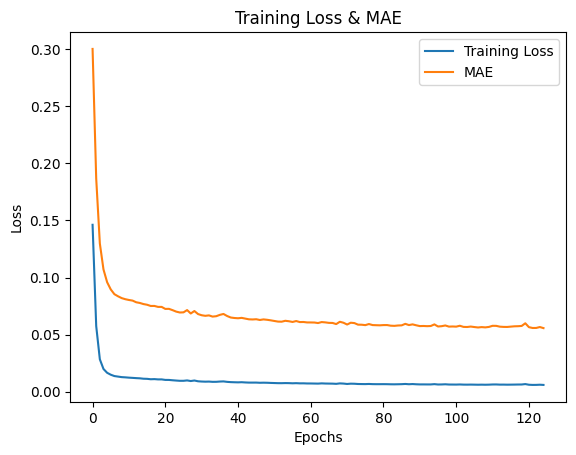

```python
plt.plot(history.history['loss'], label='Training Loss')
plt.plot(history.history['mae'], label='MAE')
plt.xlabel('Epochs')
plt.ylabel('Loss')
plt.legend()
plt.title('Training Loss & MAE')
plt.show()
```

**Evaluating The Model**

```python
model.evaluate(X_test, y_test)
```

```
6/6 ━━━━━━━━━━━━━━━━━━━━ 0s 5ms/step - loss: 0.0044 - mae: 0.0472
```

```
[0.005355208180844784, 0.05460364744067192]
```

```python
model.evaluate(X_train, y_train)
```

```
17/17 ━━━━━━━━━━━━━━━━━━━━ 0s 4ms/step - loss: 0.0069 - mae: 0.0604
```

```
[0.00597710395231843, 0.05612104758620262]
```

```python
train_predict = model.predict(X_train)
train_predict = np.array([scaler.inverse_transform(
    np.hstack([predict.reshape(-1, 1), np.zeros((predict.shape[0], X_train.shape[-1] - 1))])
)[:, 0] for predict in train_predict]).tolist()
test_predict = model.predict(X_test)
test_predict = np.array([scaler.inverse_transform(
    np.hstack([predict.reshape(-1, 1), np.zeros((predict.shape[0], X_train.shape[-1] - 1))])
)[:, 0] for predict in test_predict]).tolist()
```

```
17/17 ━━━━━━━━━━━━━━━━━━━━ 0s 13ms/step
6/6 ━━━━━━━━━━━━━━━━━━━━ 0s 4ms/step
```

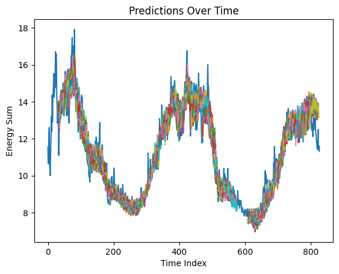

```python
plt.plot(np.arange(len(dataset["energy_sum"])), dataset["energy_sum"], label="Original Data")
for i in range(len(train_predict)):
  plt.plot(np.arange(i+look_back, i+look_back+forecast_steps), train_predict[i])
for i in range(len(train_predict), len(train_predict) + len(test_predict)):
  plt.plot(np.arange(i+2*look_back+forecast_steps, i+2*look_back+2*forecast_steps), test_predict[i-len(train_predict)])
plt.title("Predictions Over Time")
plt.xlabel("Time Index")
plt.ylabel("Energy Sum")
plt.show()
```

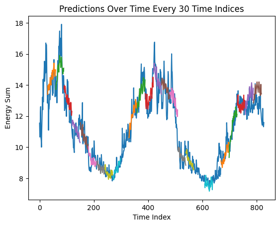

```python
plt.plot(np.arange(len(dataset["energy_sum"])), dataset["energy_sum"], label="Original Data")
for i in range(0, len(train_predict), 30):
  plt.plot(np.arange(i+look_back, i+look_back+forecast_steps), train_predict[i])
for i in range(len(train_predict), len(train_predict) + len(test_predict), 30):
  plt.plot(np.arange(i+2*look_back+forecast_steps, i+2*look_back+2*forecast_steps), test_predict[i-len(train_predict)])
plt.title("Predictions Over Time Every 30 Time Indices")
plt.xlabel("Time Index")
plt.ylabel("Energy Sum")
plt.show()
plt.show()
```

We can see here that the model is performing relatively okay, though we could probably have done more tuning and feature engineering to make it better.

Overall, if we had more data to work with, the LSTM model probably could have performed better.

### **Insights and Conclusions**

Through several visualizations and hypothesis tests, our initial data exploration and analysis revealed that energy consumption of specific households depends heavily on generalized household demographics, weather characteristics, and temporal factors; the data shows clear weekly and seasonal trends. Our time-series models support and extend these trends, and also continue a pattern of decreasing peaks in energy usage that is present in the data we have. These trends and predictions can be used by energy companies to manage energy grid operations more efficiently to prevent energy waste, and maintain energy availability to prevent outages, with knowledge of likely future energy demands.